# R Notebook

```r
#Load libraries
library(dplyr)
library(ggplot2)
library(nycflights13)
library(resampledata3)
library(tidyverse)
```

```r
united_flights <- flights %>%
  filter(carrier == "UA")%>%
  filter(!is.na(dep_delay)) %>%
  filter(!is.na(air_time)) %>%
  mutate(gain = dep_delay - arr_delay) %>%
  mutate(net_gain = dep_delay - arr_delay) %>%
  mutate(gain_per_hour = gain/(air_time/60)) %>%
  mutate(late = ifelse(dep_delay > 0, TRUE, FALSE)) %>%
  mutate(very_late = ifelse(dep_delay > 30, TRUE, FALSE))
united_flights
```

| year | month | day | dep_time | sched_dep_time | dep_delay | arr_time | sched_arr_time | arr_delay | carrier | flight | tailnum | origin | dest | air_time | distance | hour | minute | time_hour | gain | net_gain | gain_per_hour | late | very_late |
| --- | --- | --- | --- | --- | --- | --- | --- | --- | --- | --- | --- | --- | --- | --- | --- | --- | --- | --- | --- | --- | --- | --- | --- |
| 2013 | 1 | 1 | 517 | 515 | 2 | 830 | 819 | 11 | UA | 1545 | N14228 | EWR | IAH | 227 | 1400 | 5 | 15 | 2013-01-01 05:00:00 | -9 | -9 | -2.3788546 | TRUE | FALSE |
| 2013 | 1 | 1 | 533 | 529 | 4 | 850 | 830 | 20 | UA | 1714 | N24211 | LGA | IAH | 227 | 1416 | 5 | 29 | 2013-01-01 05:00:00 | -16 | -16 | -4.2290749 | TRUE | FALSE |
| 2013 | 1 | 1 | 554 | 558 | -4 | 740 | 728 | 12 | UA | 1696 | N39463 | EWR | ORD | 150 | 719 | 5 | 58 | 2013-01-01 05:00:00 | -16 | -16 | -6.4000000 | FALSE | FALSE |
| 2013 | 1 | 1 | 558 | 600 | -2 | 924 | 917 | 7 | UA | 194 | N29129 | JFK | LAX | 345 | 2475 | 6 | 0 | 2013-01-01 06:00:00 | -9 | -9 | -1.5652174 | FALSE | FALSE |
| 2013 | 1 | 1 | 558 | 600 | -2 | 923 | 937 | -14 | UA | 1124 | N53441 | EWR | SFO | 361 | 2565 | 6 | 0 | 2013-01-01 06:00:00 | 12 | 12 | 1.9944598 | FALSE | FALSE |
| 2013 | 1 | 1 | 559 | 600 | -1 | 854 | 902 | -8 | UA | 1187 | N76515 | EWR | LAS | 337 | 2227 | 6 | 0 | 2013-01-01 06:00:00 | 7 | 7 | 1.2462908 | FALSE | FALSE |
| 2013 | 1 | 1 | 607 | 607 | 0 | 858 | 915 | -17 | UA | 1077 | N53442 | EWR | MIA | 157 | 1085 | 6 | 7 | 2013-01-01 06:00:00 | 17 | 17 | 6.4968153 | FALSE | FALSE |
| 2013 | 1 | 1 | 611 | 600 | 11 | 945 | 931 | 14 | UA | 303 | N532UA | JFK | SFO | 366 | 2586 | 6 | 0 | 2013-01-01 06:00:00 | -3 | -3 | -0.4918033 | TRUE | FALSE |
| 2013 | 1 | 1 | 623 | 627 | -4 | 933 | 932 | 1 | UA | 496 | N459UA | LGA | IAH | 229 | 1416 | 6 | 27 | 2013-01-01 06:00:00 | -5 | -5 | -1.3100437 | FALSE | FALSE |
| 2013 | 1 | 1 | 628 | 630 | -2 | 1016 | 947 | 29 | UA | 1665 | N33289 | EWR | LAX | 366 | 2454 | 6 | 30 | 2013-01-01 06:00:00 | -31 | -31 | -5.0819672 | FALSE | FALSE |

[output cut: 990 more lines]

```r
NA
```

### Jacob (five most common destinations)

```r
by_destination <- united_flights %>%
  group_by(dest) %>%
  summarize(count = n()) %>%
  arrange(desc(count))
by_destination
```

| dest | count |
| --- | --- |
| IAH | 6814 |
| ORD | 6744 |
| SFO | 6728 |
| LAX | 5770 |
| DEN | 3737 |
| BOS | 3297 |
| MCO | 3191 |
| FLL | 2376 |
| LAS | 1990 |
| TPA | 1952 |

[output cut: 37 more lines]

```r
top_five_dest <- united_flights %>%
  filter(dest == "IAH" | dest == "ORD" | dest == "SFO" | dest == "LAX" | dest == "DEN")
```

```r
top_five_dest %>%
  group_by(dest) %>%
  summarize(mean = mean(net_gain)) %>%
  arrange(desc(mean))
```

| dest | mean |
| --- | --- |
| SFO | 8.695006 |
| LAX | 7.825303 |
| ORD | 7.777432 |
| DEN | 7.302382 |
| IAH | 6.861755 |

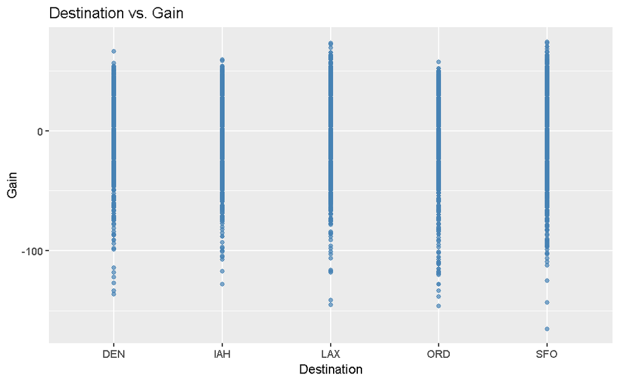

```r
ggplot(data = top_five_dest, aes(x = dest, y = net_gain))+
  geom_point(color = "steelblue", alpha = 0.7) +
  labs(title = "Destination vs. Gain",
       x = "Destination",
       y = "Gain")
```

[figure not shown]

```r
ggplot(data = top_five_dest, aes(x = dest, y = net_gain)) +
  geom_col(fill = "steelblue") +
  labs(title = "Average Net Gain by Destination",
       x = "Destination Airport",
       y = "Net Gain")
```

```r
ggplot(data = top_five_dest, mapping = aes(x = net_gain)) +
  geom_histogram(breaks=seq(-60,60, by=5), color="white", fill="steelblue") +
  facet_wrap(~ dest)   +
  labs(title = "Distributions of Gain by Destination",
       x = "Gain (minutes)",
       y = "Number of Flights")
```

[output not shown]

```r
ggplot(data=top_five_dest, aes(x=dest, y=net_gain))+
geom_boxplot(color="steelblue", fill="white")
```

[output not shown]

**Hypothesis testing**: Difference in average net gain between airports

```r
united_iah_ord <- united_flights %>%
  filter(dest == "IAH" | dest == "ORD")
united_iah_sfo <- united_flights %>%
  filter(dest == "IAH" | dest == "SFO")
united_iah_lax <- united_flights %>%
  filter(dest == "IAH" | dest == "LAX")
united_iah_den <- united_flights %>%
  filter(dest == "IAH" | dest == "DEN")
united_ord_sfo <- united_flights %>%
  filter(dest == "ORD" | dest == "SFO")
united_ord_lax <- united_flights %>%
  filter(dest == "ORD" | dest == "LAX")
united_ord_den <- united_flights %>%
  filter(dest == "ORD" | dest == "DEN")
united_sfo_lax <- united_flights %>%
  filter(dest == "SFO" | dest == "LAX")
united_sfo_den <- united_flights %>%
  filter(dest == "SFO" | dest == "DEN")
united_lax_den <- united_flights %>%
  filter(dest == "LAX" | dest == "DEN")
```

```r
t.test(net_gain~dest, data = united_iah_ord, conf.level = .95)
```

[output not shown]

```r
t.test(net_gain~dest, data = united_iah_sfo, conf.level = .95)
```

[output not shown]

```r
t.test(net_gain~dest, data = united_iah_lax, conf.level = .95)
```

[output not shown]

```r
t.test(net_gain~dest, data = united_iah_den, conf.level = .95)
```

[output not shown]

```r
t.test(net_gain~dest, data = united_ord_sfo, conf.level = .95)
```

[output not shown]

```r
t.test(net_gain~dest, data = united_ord_lax, conf.level = .95)
```

[output not shown]

```r
t.test(net_gain~dest, data = united_ord_den, conf.level = .95)
```

[output not shown]

```r
t.test(net_gain~dest, data = united_sfo_lax, conf.level = .95)
```

[output not shown]

```r
t.test(net_gain~dest, data = united_sfo_den, conf.level = .95)
```

[output not shown]

```r
t.test(net_gain~dest, data = united_lax_den, conf.level = .95)
```

[output not shown]

Clean NA

(Jack) Another common measure of interest, in addition to total gain, is the gain relative to the duration of the flight. Calculate the gain per hour by dividing the total gain by the duration in hours of each flight. Does the average gain per hour differ for flights that departed late versus those that did not? What about for flights that departed more than 30 minutes late?

```r
summary(united_flights)
```

[output not shown]

```r
ggplot(data = united_flights, mapping = aes(x = gain_per_hour)) +
      geom_histogram(color = "white",bins = 50,fill = "cadetblue3") +
      labs(y = "Number of Flights",
       x = "Flight Time Gain per Hour (minutes)")


# Calculate percentage in range 0 to 30
# Calculate percentages and quantiles
percentage_0_30 <- mean(united_flights$gain_per_hour >= 0 &
                        united_flights$gain_per_hour <= 30,
                        na.rm = TRUE) * 100

quant75 <- quantile(united_flights$gain_per_hour, 0.75, na.rm = TRUE)

ggplot(united_flights, aes(x = gain_per_hour)) +
  geom_histogram(aes(y = ..density..), bins = 50, color = "white", fill = "cadetblue3") +
  geom_vline(xintercept = c(0, 30), color = "darkgreen", linetype = "dashed", size = 1) +
  geom_vline(xintercept = quant75, color = "red", linetype = "dashed", size = 1) +
  annotate("text", x = 15, y = 0.03, hjust = -0.45,
           label = paste0("0-30 min range: \n   ", round(percentage_0_30, 1), "% flights"),
           color = "darkgreen", size = 4) +
  annotate("text", x = quant75, y = 0.05, hjust = -0.1,
           label = paste0("75th percentile:\n   ", round(quant75, 2)),
           color = "red", size = 4) +
  labs(x = "Flight Time Gain per Hour (minutes)",
       y = "Density",
       title = "Flight Time Gain per Hour (minutes) - Density Histogram")
```

[output not shown]

```r
# Calculate percentage in range 0 to 30
# Calculate percentages and quantiles
percentage_0_30 <- mean(united_flights$dep_delay >= 0 &
                        united_flights$dep_delay <= 30,
                        na.rm = TRUE) * 100

quant75 <- quantile(united_flights$dep_delay, 0.75, na.rm = TRUE)

ggplot(united_flights, aes(x = dep_delay)) +
  geom_histogram(aes(y = ..density..), bins = 50, color = "white", fill = "cadetblue3") +
  geom_vline(xintercept = c(0, 30), color = "darkgreen", linetype = "dashed", size = 1) +
  geom_vline(xintercept = quant75, color = "red", linetype = "dashed", size = 1) +
  annotate("text", x = 15, y = 0.03, hjust = -0.45,
           label = paste0("0-30 min range: \n   ", round(percentage_0_30, 1), "% flights"),
           color = "darkgreen", size = 4) +
  annotate("text", x = quant75, y = 0.04, hjust = -0.3,
           label = paste0("75th percentile:", round(quant75, 2)),
           color = "red", size = 4) +
  labs(x = "Flight Departure Delay (minutes)",
       y = "Density",
       title = "Flight Departure Delay (minutes) - Density Histogram")
```

[output not shown]

```r
ggplot(united_flights, aes(x=dep_delay, y = gain_per_hour)) +
  geom_point(color = "cadetblue3") +
  geom_smooth(method = "lm", se = TRUE, fullrange = TRUE) +
  labs(x = "Departure Delay (minutes)",
       y = "Flight Time Gain per Hour (minutes)")
  geom_smooth(method = "lm", se = TRUE, fullrange = TRUE,
              color = "lightblue",
              fill = "lightblue")
```

[output not shown]

```r
united_flights_delay_below_30min <-united_flights %>%
  filter(dep_delay <= 30)
```

```r
ggplot(united_flights, aes(x=dep_delay, y = gain_per_hour, color = very_late)) +
  geom_point() +
  geom_smooth(method = "lm", se = TRUE, fullrange = TRUE) +
  labs(x = "Departure Delay (minutes)",
       y = "Flight Time Gain per Hour (minutes)",
       color = "Delay") +
  scale_color_manual(values = c("FALSE" =  "cadetblue3", "TRUE" ="red"),
                     labels = c("On Time or Early", "Very Late (>30 mins)"))
```

[output not shown]

## Analyzing flights not very late <30min

```r
united_flights_delay_below_30min <-united_flights %>%
  filter(dep_delay <= 30)
```

```r
ggplot(united_flights_delay_below_30min, aes(x=dep_delay, y = gain_per_hour)) +
  geom_point(color = "cadetblue3") +
  geom_smooth(method = "lm", se = TRUE, fullrange = TRUE,
              color = "lightblue",
              fill = "lightblue")


ggplot(united_flights_delay_below_30min, aes(x=dep_delay, y = gain_per_hour, color = late)) +
  geom_point() +
  geom_smooth(method = "lm", se = TRUE, fullrange = TRUE) +
  labs(x = "Departure Delay (minutes)",
       y = "Flight Time Gain per Hour (minutes)",
       color = "Delay") +
  scale_color_manual(values = c("FALSE" =  "cadetblue3", "TRUE" ="indianred"),
                     labels = c("On Time or Early", "Late (<30 mins)"))
```

[output not shown]

Once departure delay stays under ~30 minutes, United pilots neither systematically gain nor lose more. The strong negative relationship seen in the full dataset completely disappears.

## Hypothesis Analysis

Does gain per hour on flights with slightly late (<30 minutes) departure differ from flights overall?

```r
overall_mean <- mean(united_flights$gain_per_hour)

t.test(united_flights_delay_below_30min$gain_per_hour, mu = overall_mean, conf.level = 0.95)
```

[output not shown]

**Result:** Flights that departed 30 minutes late or better recovered an average of 3.69 minutes per flight hour in the air. United Airlines’ overall averageis 3.61 minutes per hour. A one-sample t-test shows that flights with small or no departure delay recover slightly but significantly more time than the airline’s overall average: p = 0.022). We are 95% confident that the true average recovery for these flights lies between 3.62 and 3.77 minutes per hour.

Do United Airlines flights that depart more than 30 minutes late recover significantly less time in the air than flights that depart within 30 minutes of schedule?

```r
t.test(gain_per_hour ~ very_late, data = united_flights,
       alternative = "greater", var.equal = TRUE, conf.level = 0.95)
```

[output not shown]

Flights delayed more than 30 minutes recover, on average, about 38 seconds per hour flown than flights delayed 30 minutes or less. A one-sided t-test confirms this disadvantage is highly significant p ≈ 9.01e-10, and we are 95% confident the true disadvantage is at least 0.46 minutes per hour. Although there is a difference. It is less than a minute on average. A 30-minute ground delay does not translate into a dramatically worse air_time performance.